# R Notebook

## 1. Pessoas que assistem o seriado Game of Thrones gostam de episodios com morte de personagens?

Ja é marca de Game of Thrones que muitos personagens importantes morrem durante o decorrer das temporadas. É normal que as pessoas assistindo se sintam com raiva apos a perda de um personagem com o qual laços foram criados.

O que os usuarios do IMDB acham disso? O sentimento de perda do personagem afeta na nota que o usuario avalia o episodio?

### 1.1 Correlacao da nota com morte de personagens

A conta da morte de personagens leva em consideracao apenas mortes de personagens principais e secundarios, nao leva em consideracao mortes de figurantes.

```r
episodesGameOfThrones = read_csv(here("data/series_from_imdb.csv"),
                    progress = FALSE,
                    col_types = cols(.default = col_double(),
                                     series_name = col_character(),
                                     episode = col_character(),
                                     url = col_character(),
                                     season = col_character())) %>%
    filter(series_name == "Game of Thrones")
```

```r
got = read_csv(here("data/got.csv"),
                    progress = FALSE,
                    col_types = cols(.default = col_double(),
                                     season = col_character(),
                                     ep_id = col_character(),
                                     n_importante = col_integer(),
                                     n_secundario = col_integer(),
                                     n_total = col_integer()))
```

#### Correlacao entre numero de mortes com a nota do episodio

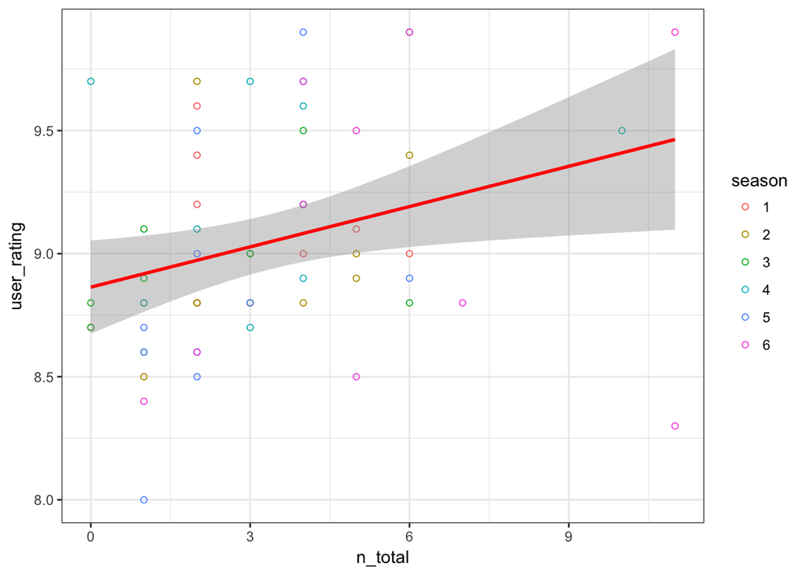

```r
result <- episodesGameOfThrones[,c("episode","series_ep","season", "season_ep", "user_rating")]

result <- result %>%
  cbind(got)

ggplot(result, aes(x=n_total, y=user_rating, color = season)) +
  geom_point(shape=1) + geom_smooth(method=lm , color="red", se=TRUE) # Add linear regression line
```

#### Numero total de persogens mortos por temporada

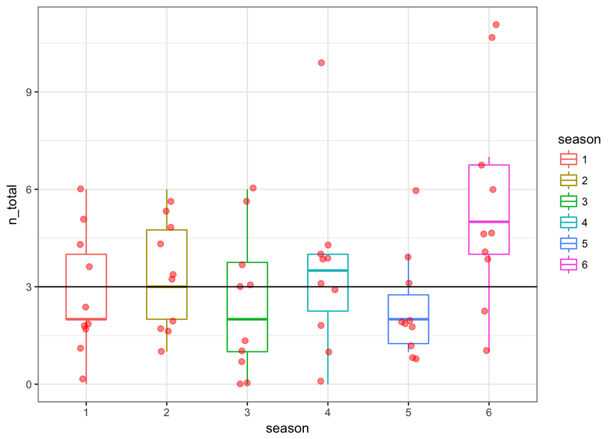

```r
median <- median(result$n_total)

result %>%
    ggplot(aes(x = season, y = n_total, color = season)) +
    geom_boxplot(width = .5, outlier.color = NA) +
    geom_jitter(width = .1, size = 2, alpha = .5, color = "red") +
    geom_hline(yintercept = median)
```

Ha uma correlacao positiva fraca entre o numero de mortes por episodios e a nota atribuida pelos usuarios ao episodio.

Quando ha um numero muito alto de mortes geralmente se da devido a um grande acontecimento na serie, como uma guerra, esses episodios tendem a ter uma nota maior e sao de maior audiencia.

Dentre as temporadas disponiveis podemos notar que mortes de personagens nao afentam negativamente a nota atribuida pelos usuario do site IMDB.

[source: https://deathtimeline.com/](https://deathtimeline.com/)

## 2. A qualidade da serie House of Cards vem aumentando junto com o numero de assinantes do Netflix?

O site de streaming Netflix vem ganhando cada vez mais assinantes mundialmente. O servico tem como caracteristica uma maior promocao de conteudo proprio ao inves de conteudo criado por terceiros.

Nao sao divulgados dados de audiencia por serie, porem a cada trimestre eh divulgado o numero total de assinantes do servico.

É possivel notar um aumento da qualidade da serie House of Cards, criada pelo proprio site, a medida que mais assinantes possuem o servico?

Olharemos para a serie House of Cards.

```r
episodesHouseOfCards = read_csv(here("data/episodesHouseOfCardsData.csv"),
                    progress = FALSE,
                    col_types = cols(.default = col_double(),
                                     series_name = col_character(),
                                     episode = col_character(),
                                     url = col_character(),
                                     season = col_character(),
                                     assinantes = col_double(),
                                     ano = col_integer()))
```

#### O numero de assinantes do Netflix cresceu constantemente durante a duracao da serie.

Numeros em milhoes

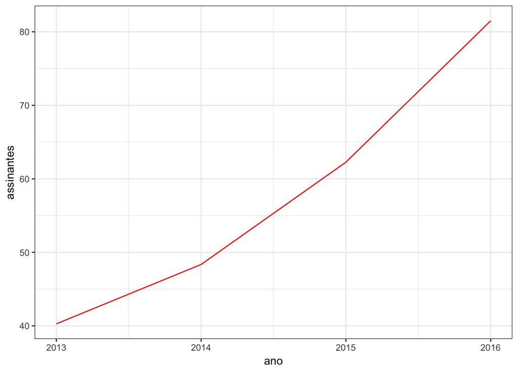

```r
netflixData = read_csv(here("data/netflixData.csv"),
                    progress = FALSE,
                    col_types = cols(.default = col_double(),
                                     ano = col_integer(),
                                     assinantes = col_double()))

netflixData %>%
    ggplot(aes(x = ano, y = assinantes))  +
    geom_line(color="red")
```

#### A qualidade da serie acompanha o crescimento no numero de assinantes?

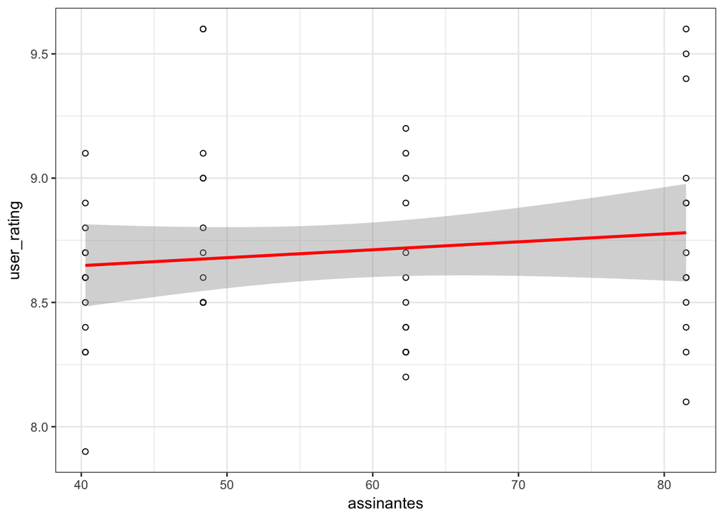

```r
ggplot(episodesHouseOfCards, aes(x=assinantes, y=user_rating)) +
  geom_point(shape=1) + geom_smooth(method=lm , color="red", se=TRUE) # Add linear regression line
```

#### Qualidade da serie por ano

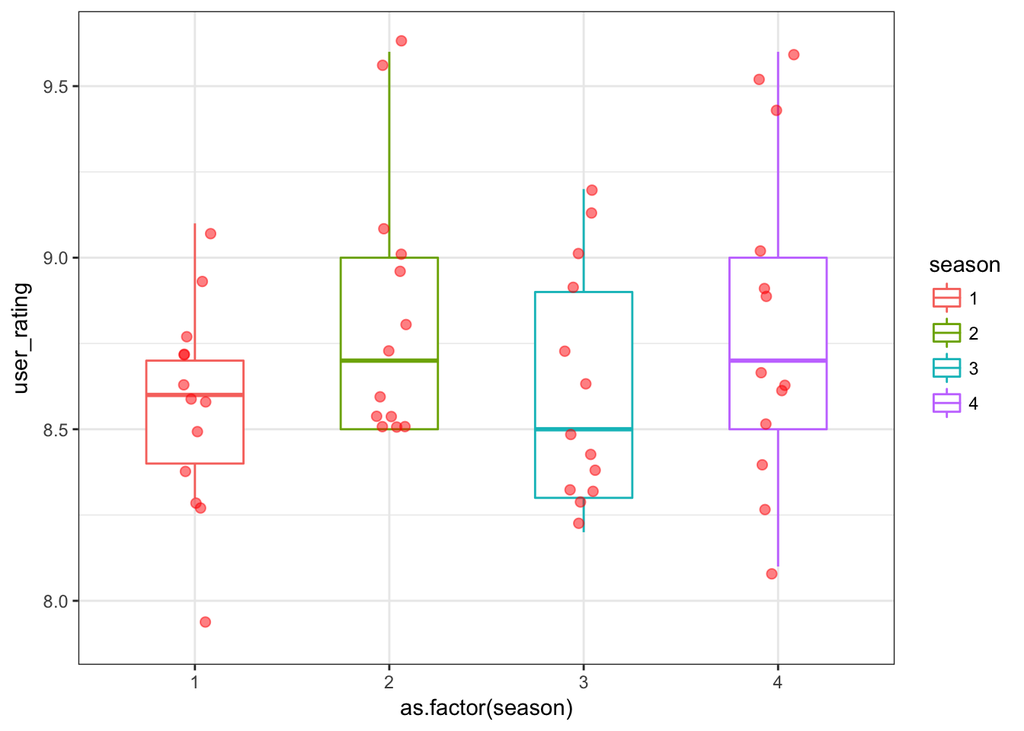

```r
episodesHouseOfCards %>%
    ggplot(aes(x = as.factor(season), y = user_rating, color = season)) +
    geom_boxplot(width = .5, outlier.color = NA) +
    geom_jitter(width = .1, size = 2, alpha = .5, color = "red")
```

Nossa amostra de series nao eh sufiente para determinar a qualidade do conteudo criado pelo Netflix. Porem no caso de House of Cards podemos notar que o numero crescentes de usuarios do site nao influencia na qualidade da serie, que continua estavel durente sua exibicao.

[source: https://www.statista.com/statistics/250934/quarterly-number-of-netflix-streaming-subscribers-worldwide/](https://www.statista.com/statistics/250934/quarterly-number-of-netflix-streaming-subscribers-worldwide/)